# Assignment 3 Task 4: Naples Reef (2010) purple urchins

Karina Johnston

10/27/2021

This assignment will analyze sea urchin data from the Santa Barbara Coastal Long Term Ecological Research program. Data for purple (*Strongylocentrotus purpuratus*) urchins observed at Naples Reef along the Santa Barbara coast are analyzed. Exploratory figures and a finalized summary table are produced, exploring data visualization techniques and summary statistics.

Citation: Reed, D. 2020. SBC LTER: Reef: Long-term experiment: Kelp removal: Urchin size frequency distribution ver 20. Environmental Data Initiative. Accessed 2010-10-27. (https://doi.org/10.6073/pasta/5a1e9ef03aa47bd2225c0bb98a02a63b)

```r
knitr::opts_chunk$set(echo = TRUE, warning = FALSE, message = FALSE)

# Attach the following packages into the setup code chunk and change the settings for reporting warnings and messages (above)
library(tidyverse)
library(kableExtra)
library(here)
library(janitor)
library(lubridate)
```

### Read in the data

This step reads in the urchin data .csv file from within the project folder and creates a new dataframe `urchin_data`, followed by a step to change the column headers to lower snake case using the function `clean_names()` found in the `janitor` package.

```r
urchin_data <- read_csv(here("data", "urchins.csv")) %>%
  clean_names()
```

### Section 1: Data wrangling

First, the urchins data are filtered to only include Naples Reef data for purple urchins in 2010 and saved to a new dataframe `purple_naples_2010`.

```r
# creates the new dataframe beginning with urchin_data
purple_naples_2010 <- urchin_data %>%

# updates the date column to be Date format and adds a year column
  mutate(date = mdy(date)) %>%
  mutate(year = year(date)) %>%

# filters only purple urchins from 2010 and Naples Reef
  filter(common_name == "Purple Urchin",
         site == "NAPL",
         year == "2010")
```

### Section 2: Exploratory visualization

Next, an exploratory histogram and QQ-plot for the size distribution of purple urchins at Naples Reef in 2010 are created to assess normality (faceted graphs).

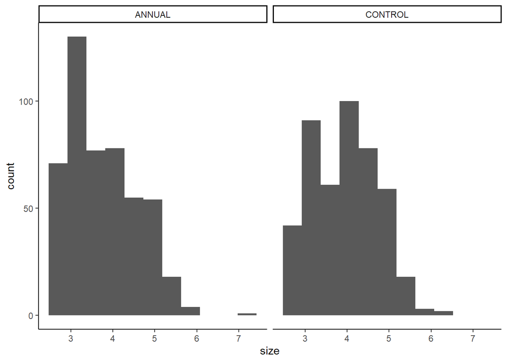

```r
# creates a histogram with fewer bins to better visualize the normality of the data
ggplot(data = purple_naples_2010, aes(x = size)) +
  geom_histogram(bins = 11) +
  facet_wrap(~ treatment) +
  theme_classic()
```

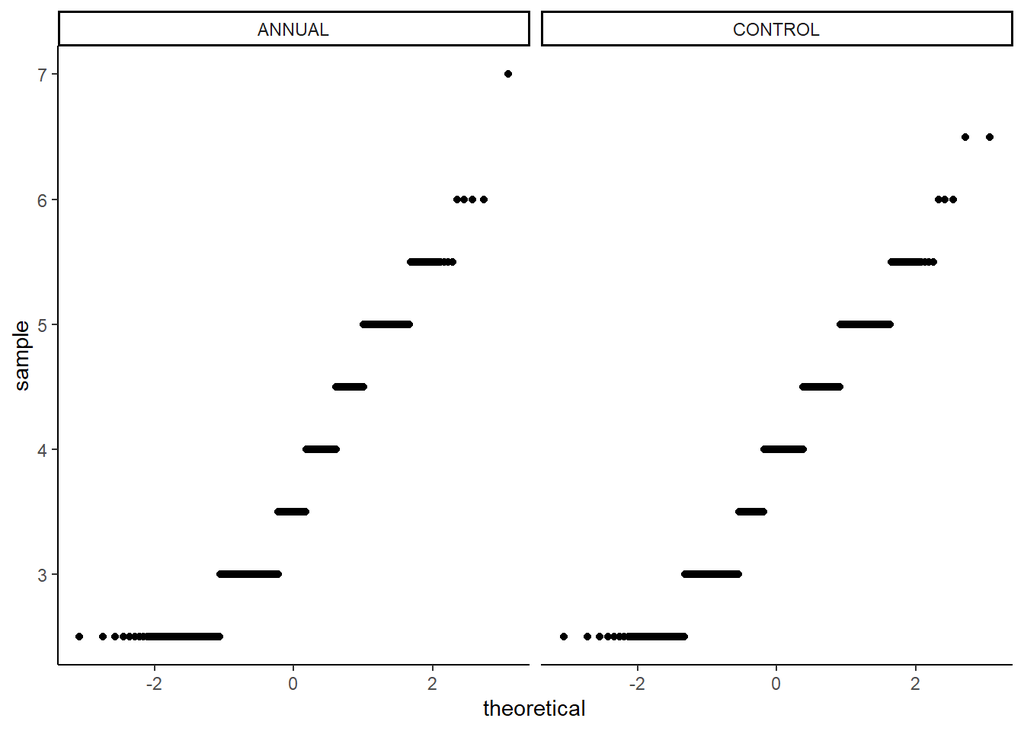

```r
# creates a quantile-quantile plot to visualize normality
ggplot(data = purple_naples_2010, aes(sample = size)) +
  geom_qq() +
  facet_wrap(~ treatment) +
  theme_classic()
```

Based on the visualizations in the histogram and Q-Q plot, the data appear fairly normally distributed, with potentially a couple of outliers (especially on the positive tail of the annual treatment). Both seem largely unimodal, though when you increase the numbers of bins, there are more than one peak. However, that could be a result of the sampling methodology as binned data (measured to 0.5 cm accuracy). The Q-Q plot is roughly in a line, though also exhibits trends from the binned data.

### Section 3: Finalized basic summary table

This section creates a finalized basic summary table (with table caption above) of descriptive statistics for both groups, including mean, SD, median, and sample size.

```r
purple_naples_summary_stats <- purple_naples_2010 %>%

# these functions group by species and produce the summary statistics (rounded)
  group_by(treatment) %>%
  summarize(mean_size_cm = round(mean(size), 2),
            sd_size = round(sd(size), 2),
            median_size_cm = round(median(size), 1),
            sample_size = n())

# these functions update the table to be cleaner, easier to read, and visually appealing
kable(purple_naples_summary_stats,
      col.names = c("Treatment", # changes the column names
                    "Mean Diameter (cm)",
                    "Standard Deviation (cm)",
                    "Median Diameter (cm)",
                    "Sample Size"),
      align = "lcccc", # changes the alignment of the columns

# adds a caption
      caption = "Table 1. Summary statistics for diameter (cm) size distributions of purple urchins on Naples Reef in 2010 based on experimental treatment (Johnston).") %>%

# better lines within the table
kable_classic(full_width = F)
```

Table 1. Summary statistics for diameter (cm) size distributions of purple urchins on Naples Reef in 2010 based on experimental treatment (Johnston).

| Treatment | Mean Diameter (cm) | Standard Deviation (cm) | Median Diameter (cm) | Sample Size |
| --- | --- | --- | --- | --- |
| ANNUAL | 3.68 | 0.90 | 3.5 | 488 |
| CONTROL | 3.89 | 0.87 | 4.0 | 454 |

#### End of Assignment 3 Task 4